# Regression Analysis #1

Aleksander Molak

November 28, 2019

## Read in the data

```r
data <- read.spss(file.path(path, data_file), to.data.frame = TRUE)
```

```
## re-encoding from UTF-8
```

## Exploratory data analysis

```r
# Number of observations
dim(data)[1]
```

```
## [1] 402
```

```r
summary(data)
```

```
##      MONEY                         EDUC         SEX           FWI
##  Min.   :  0.00   elementary         :102   female:202   Min.   :  0.00
##  1st Qu.: 39.02   vocational         :100   male  :200   1st Qu.: 44.08
##  Median : 52.95   general highschool : 49                Median : 77.49
##  Mean   : 53.18   profiled highschool: 51                Mean   : 70.78
##  3rd Qu.: 67.81   higher             :100                3rd Qu.:100.00
##  Max.   :100.00                                          Max.   :250.00
##        CI               AQ               II
##  Min.   :  0.00   Min.   :  0.00   Min.   :  0.00
##  1st Qu.: 34.25   1st Qu.: 38.35   1st Qu.: 37.95
##  Median : 48.48   Median : 51.91   Median : 51.95
##  Mean   : 49.63   Mean   : 52.38   Mean   : 52.18
##  3rd Qu.: 62.69   3rd Qu.: 67.03   3rd Qu.: 66.47
##  Max.   :100.00   Max.   :100.00   Max.   :100.00
```

There’s no missing data in the dataset.

There are two categorical variables in the dataset:

- `EDUC` with 5 levels
- `SEX` with two levels

The latter can be simply encoded as a binary variable. The former needs to be one-hot encoded.

## Recode & clean categorical variables

We will use `male` as our reference point. It will be encoded as `0`.

```r
# Recode `SEX`
data$SEX <- dplyr::recode(data$SEX, male = 0, female = 1)
```

Education is a categorical variable - categories like `general highschool` or `profiled highschool` do not seem to be easily translatable to a interval or ratio scale. Let’s perform one-hot encoding for `EDUC`:

```r
edu <- data %>% select(EDUC)
edu_dummy <- dummies::dummy(edu$EDUC, sep = '_')
data_ohe <- cbind(data, edu_dummy)
```

Now, let’s clean the data (remove the original `EDUC` column) and pick our reference point for education. On one hand, I’d like to have a reference somewhere in the middle, which could be a good basis for neat interpretation. On the other hand, the middle category (`general highscholool`) has less observations than many other categories. Taking this into account, I’ll choose `higher` as the reference point, to minimize the coefficient standard errors.

```r
data_ohe <- plyr::rename(data_ohe,
                         replace = c('EDUC_profiled highschool' = 'EDUC_profiled_highschool',
                                     'EDUC_general highschool'  = 'EDUC_general_highschool'))
# #### Knitr throws an error here: save the data to csv and re-read ####
# data_clean <- data_ohe %>% select(-c(EDUC))
# data_clean <- data_clean %>% select(-c(EDUC_higher))
# #
# write.csv(data_clean, file.path(path, 'data_clean.csv'), row.names = FALSE)
data_clean <- read.csv(file.path(path, 'data_clean.csv'))
```

## Examine numerical variables

### Histograms

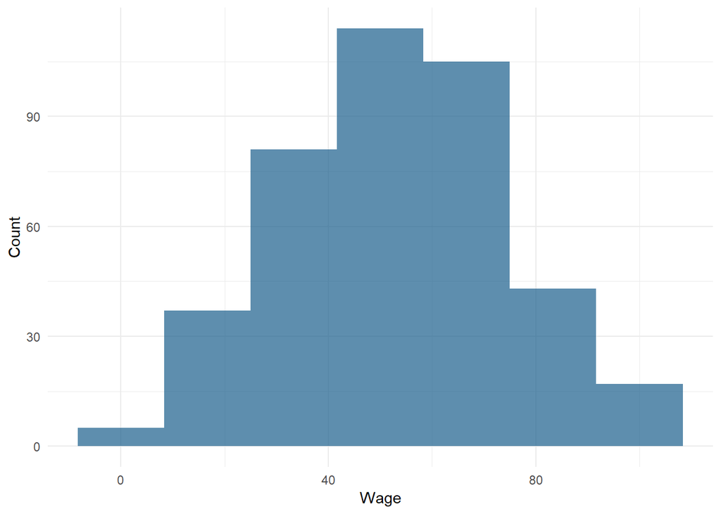

Figure 1. Histogram: Wage

```r
# Histogram of DV - MONEY
ggplot(data_clean, aes(MONEY)) + geom_histogram(bins=7, fill=color, alpha=.7) +
                           xlab('Wage') +
                           ylab('Count') +
                           theme_minimal()
```

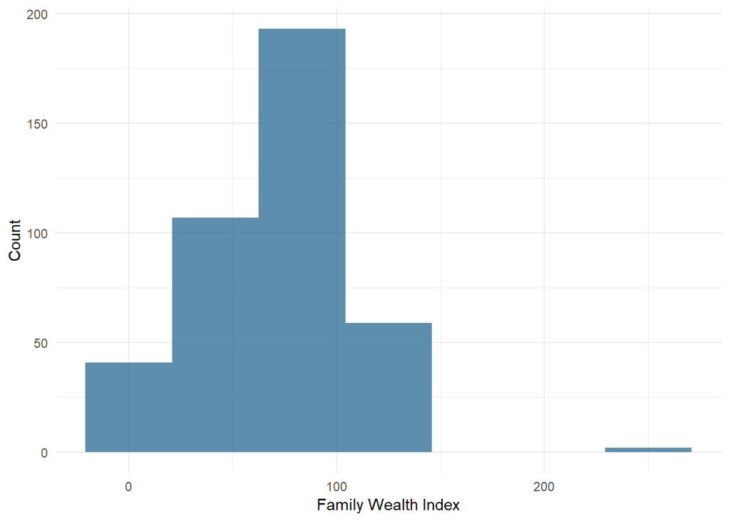

Figure 2. Histogram: Family Wealth Index

```r
# Histogram of DV - MONEY
ggplot(data_clean, aes(FWI)) + geom_histogram(bins=7, fill=color, alpha=.7) +
                           xlab('Family Wealth Index') +
                           ylab('Count') +
                           theme_minimal()
```

It seems that `FWI` contains a potentially problematic observation(s). There is a small ‘bump’ in the histogram around the value of `250`. It’s much higher than most other values for this variable and much higher than `max` of other numerical variables (`100`). Let’s remeber about this and get back to this issue when generating scatterplots.

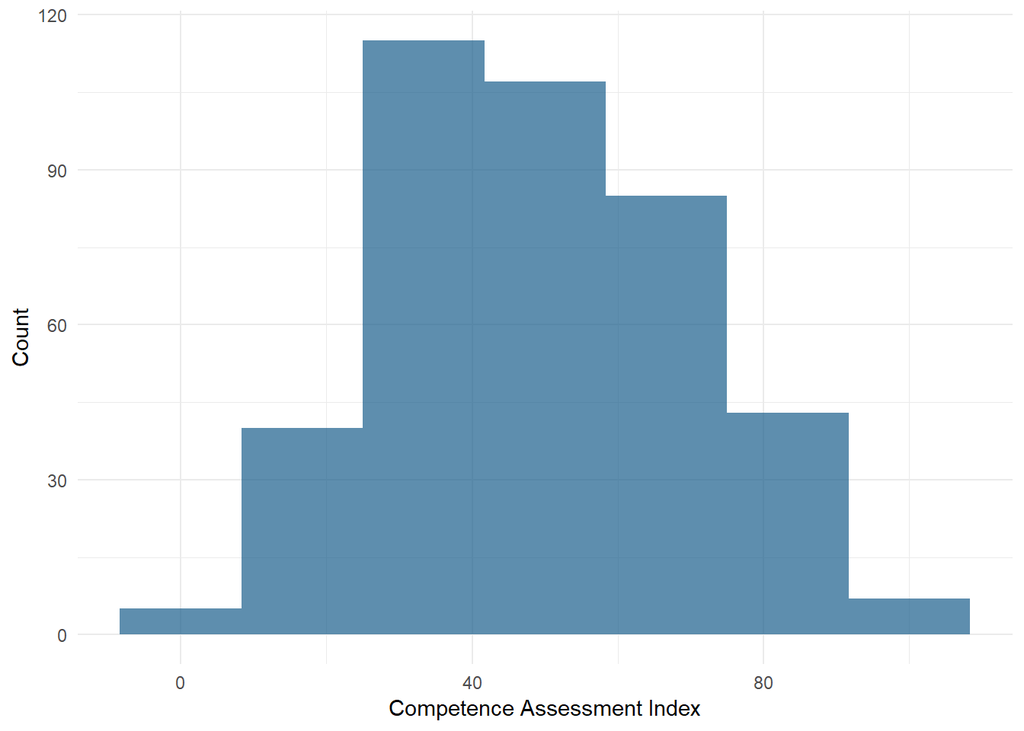

Figure 4. Histogram: Competence Assessment Index

```r
# Histogram of DV - MONEY
ggplot(data_clean, aes(CI)) + geom_histogram(bins=7, fill=color, alpha=.7) +
                           xlab('Competence Assessment Index') +
                           ylab('Count') +
                           theme_minimal()
```

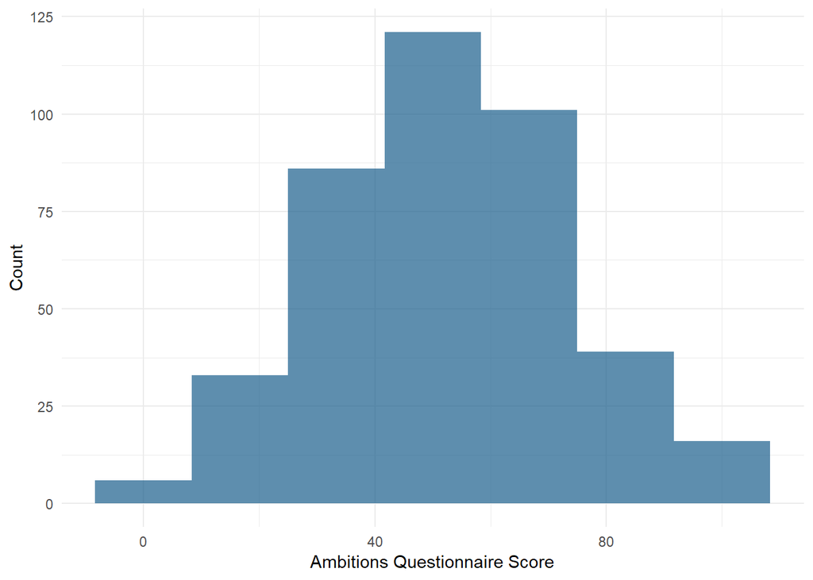

Figure 5. Histogram: Ambitions Questionnaire Score

```r
# Histogram of DV - MONEY
ggplot(data_clean, aes(AQ)) + geom_histogram(bins=7, fill=color, alpha=.7) +
                           xlab('Ambitions Questionnaire Score') +
                           ylab('Count') +
                           theme_minimal()
```

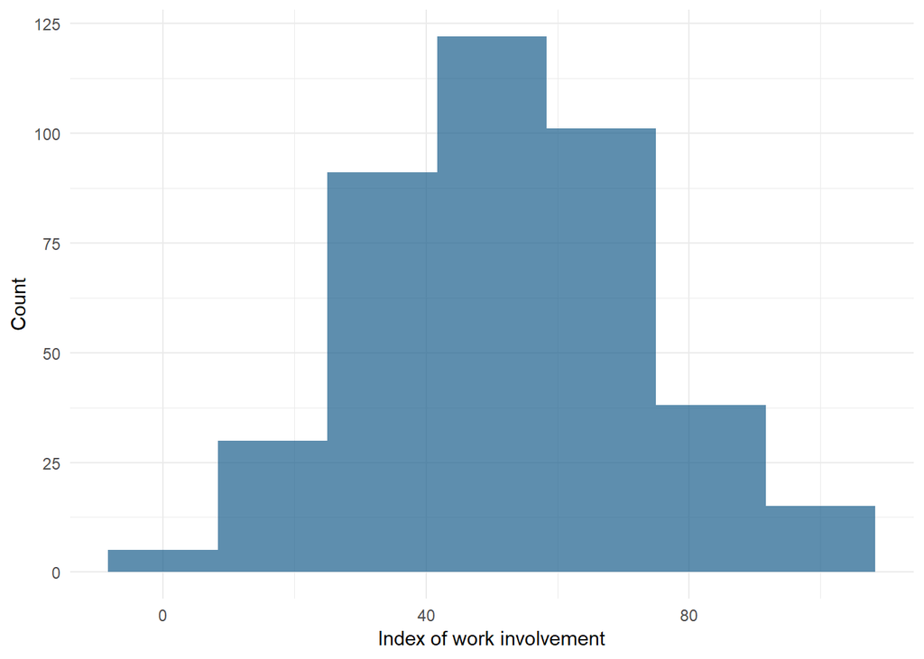

Figure 6. Histogram: Index of Work Involvement

```r
# Histogram of DV - MONEY
ggplot(data_clean, aes(II)) + geom_histogram(bins=7, fill=color, alpha=.7) +
                           xlab('Index of work involvement') +
                           ylab('Count') +
                           theme_minimal()
```

### Check the relationship between variables

I’ll now generate scatterplots for DV and all numerical IVs. I will use partial transparency to indicate strength of the relation in case of the overlapping data points. Locally estimated scatterplot smoothing (LOESS) regression lines (Cleveland, 1979; Wickham, 2016) will be added on top of each scatterplot.

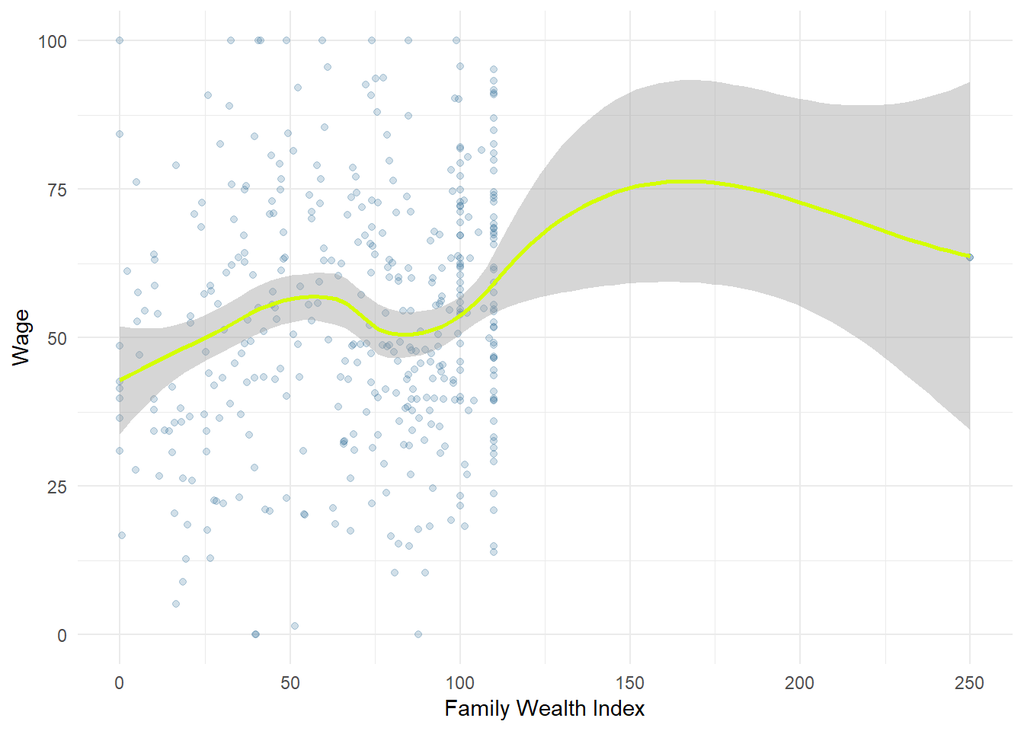

Figure 7. Relationship between Wage and Family Wealth Index with added LOESS regression line.

```r
ggplot(data_clean, aes(FWI, MONEY)) + geom_point(color = color,
                                          alpha = .2) +
                               xlab('Family Wealth Index') +
                               ylab('Wage') +
                               geom_smooth(color  = color2,
                                           method ='loess') +
                               theme_minimal()
```

It seems that the observation taking the value of `250` is a serious outlier. Let’s make sure if this in an issue with only one data point.

```r
data_clean$FWI[data_clean$FWI > 100]
```

```
##  [1] 101.41 102.11 102.12 102.60 104.19 106.93 108.62 110.00 110.00 110.00
## [11] 110.00 110.00 110.00 110.00 110.00 110.00 110.00 110.00 110.00 110.00
## [21] 110.00 110.00 110.00 110.00 110.00 110.00 110.00 110.00 110.00 110.00
## [31] 110.00 110.00 110.00 110.00 110.00 110.00 110.00 110.00 110.00 110.00
## [41] 250.00 101.13 102.36 102.92 105.47 109.84 110.00 110.00 110.00 110.00
## [51] 110.00 110.00 110.00 110.00 110.00 110.00 110.00 110.00 110.00 110.00
## [61] 110.00 110.00 110.00 110.00 110.00 102.44 110.00 101.49 106.25 250.00
```

```r
length(data_clean$FWI[data_clean$FWI > 100])
```

```
## [1] 70
```

There are 70 observations with values `> 100`. It seems reasonable to assume that for `FWI` the maximum value is `110`.

Let’s see how many observations take values `> 110`:

```r
length(data_clean$FWI[data_clean$FWI > 110])
```

```
## [1] 2
```

There are two observations like this. Let’s look at them closely:

```r
data_clean$FWI[data_clean$FWI > 110]
```

```
## [1] 250 250
```

Both take exactly the same value (`250`).

```r
for (col in colnames(data_clean)) {
  cat('Variable', col, 'values for all records with FWI > 110:\n', sep = ' ')
  cat(unlist(data_clean %>% filter(FWI > 110) %>% select(col)))
  cat('\n\n')
}
```

```
## Variable MONEY values for all records with FWI > 110:
## 63.55 63.55
##
## Variable SEX values for all records with FWI > 110:
## 1 1
##
## Variable FWI values for all records with FWI > 110:
## 250 250
##
## Variable CI values for all records with FWI > 110:
## 60 60
##
## Variable AQ values for all records with FWI > 110:
## 93.56 93.56
##
## Variable II values for all records with FWI > 110:
## 83.51 83.51
##
## Variable EDUC_elementary values for all records with FWI > 110:
## 1 1
##
## Variable EDUC_vocational values for all records with FWI > 110:
## 0 0
##
## Variable EDUC_general_highschool values for all records with FWI > 110:
## 0 0
##
## Variable EDUC_profiled_highschool values for all records with FWI > 110:
## 0 0
```

It seems that both cases of `FWI == 250` are in fact the same observation, but doubled.

We don’t know if this is a result of human coding error or an artifact generated by some ETL process on the way. As the dataset is big enough to do so, I decide to delete both observation with `FWI > 110`.

```r
# Remove obs with `FWI` > 110
data_clean <- data_clean %>% filter(FWI <= 110)
```

```r
# Sanity check
sum(data_clean$FWI > 110)
```

```
## [1] 0
```

Another potential problem in the `FWI` is it’s max value. From the scatterplot it seems that there’s a bounding value of `100` and then another one at `110`. This is a possible indicator of measurement error. Another explanation could be that, there are ceiling effects at `100` and `110` for some groups or sub-groups for `FWI` scale.

Note that variance of `FWI` seems to be smaller between `100` and `110` than in the range of 0 - 100. This might be problematic in the context of homo-/heteroscedasticity. I’ll keep that in mind and move forward. We’ll come back to these issues when diagnosing the model.

Now let’s get back to scatter plots.

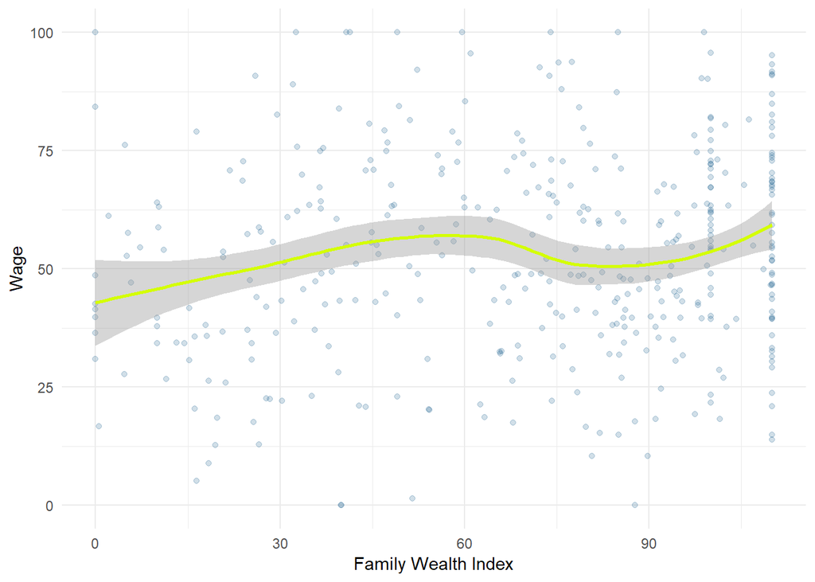

Figure 8. Relationship between Wage and Family Wealth Index with added LOESS regression line (outliers removed).

```r
ggplot(data_clean, aes(FWI, MONEY)) + geom_point(color = color,
                                          alpha = .2) +
                               xlab('Family Wealth Index') +
                               ylab('Wage') +
                               geom_smooth(color  = color2,
                                           method ='loess') +
                               theme_minimal()
```

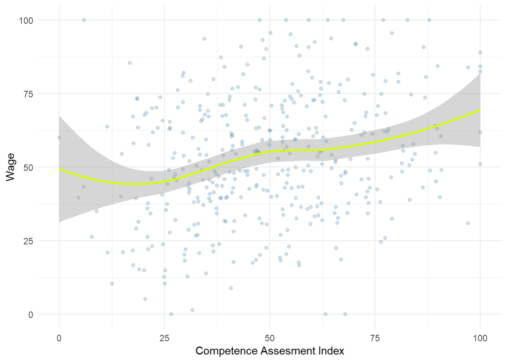

Figure 9. Relationship between Wage and Competence Assesment Index with added LOESS regression line.

```r
ggplot(data_clean, aes(CI, MONEY)) + geom_point(color = color,
                                          alpha = .2) +
                               xlab('Competence Assesment Index') +
                               ylab('Wage') +
                               geom_smooth(color  = color2,
                                           method ='loess') +
                               theme_minimal()
```

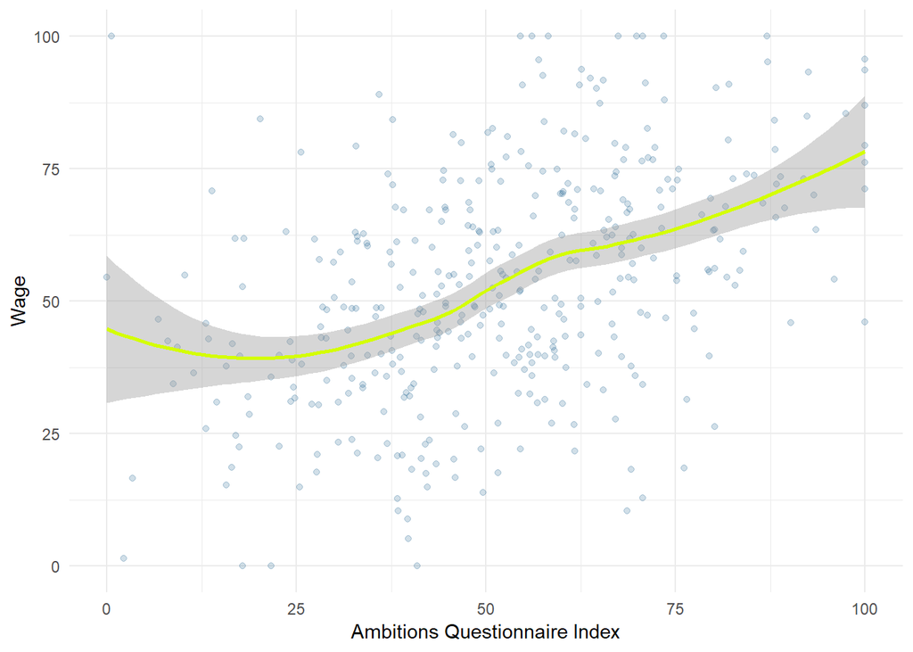

Figure 10. Relationship between Wage and Ambitions Questionnaire Index with added LOESS regression line.

```r
ggplot(data_clean, aes(AQ, MONEY)) + geom_point(color = color,
                                          alpha = .2) +
                               xlab('Ambitions Questionnaire Index') +
                               ylab('Wage') +
                               geom_smooth(color  = color2,
                                           method ='loess') +
                               theme_minimal()
```

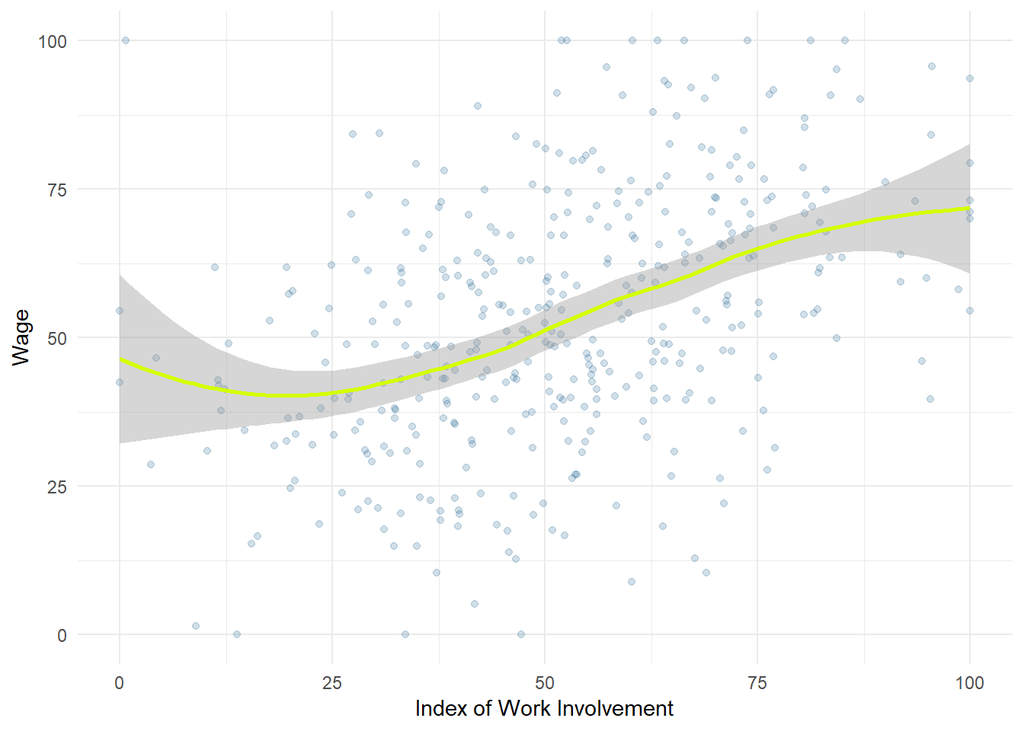

Figure 11. Relationship between Wage and Index of Work Involvement with added LOESS regression line.

```r
ggplot(data_clean, aes(II, MONEY)) + geom_point(color = color,
                                          alpha = .2) +
                               xlab('Index of Work Involvement') +
                               ylab('Wage') +
                               geom_smooth(color  = color2,
                                           method ='loess') +
                               theme_minimal()
```

## Assumptions of linear regression

### Linearity

From the scatterplots above we can see that most of the variables have reasonably linear relationship with our $DV$. Again, `FWI` is the most controversial in this regard. Let’s run full diagnostics to check to what extent it’s problematic.

To run diagnostics we need to fit the model first.

```r
model_1 <- lm(MONEY ~ ., data = data_clean)
```

Let’s see model summary.

```r
summary(model_1)
```

```
##
## Call:
## lm(formula = MONEY ~ ., data = data_clean)
##
## Residuals:
##     Min      1Q  Median      3Q     Max
## -46.687 -10.426   0.527   9.072 121.373
##
## Coefficients:
##                           Estimate Std. Error t value Pr(>|t|)
## (Intercept)               -8.95837    4.07671  -2.197  0.02858 *
## SEX                       -5.82127    1.79324  -3.246  0.00127 **
## FWI                        0.39368    0.04741   8.303 1.69e-15 ***
## CI                         0.53242    0.04119  12.925  < 2e-16 ***
## AQ                         0.26817    0.08384   3.199  0.00149 **
## II                         0.24043    0.08515   2.823  0.00499 **
## EDUC_elementary          -29.64181    3.82881  -7.742 8.52e-14 ***
## EDUC_vocational          -22.44630    3.37066  -6.659 9.37e-11 ***
## EDUC_general_highschool   -8.98810    3.03276  -2.964  0.00323 **
## EDUC_profiled_highschool -10.05573    2.96285  -3.394  0.00076 ***
## ---
## Signif. codes:  0 '***' 0.001 '**' 0.01 '*' 0.05 '.' 0.1 ' ' 1
##
## Residual standard error: 15.47 on 390 degrees of freedom
## Multiple R-squared:  0.4885, Adjusted R-squared:  0.4767
## F-statistic: 41.39 on 9 and 390 DF,  p-value: < 2.2e-16
```

According to repective $t$ and $p$ values all the variables are significant predictors of the outcome variable. As indicated by the $F$ test ($F(9, 390) = 41.39,\ p < .001$) `model_1` provides a better fit to the data than a model that contains no independent variables. It remains an open question if dummy re-coded `EDUC` as category is a significant predictor of $DV$. We’ll test for this later.

### Outliers and influential cases

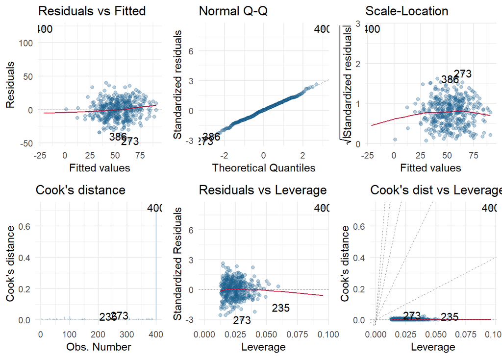

Figure 12. Diagnostic plots for `model_1`

```r
autoplot(model_1, colour = color, smooth.colour = color3,
         alpha = .3,
         which = 1:6,
         ncol  = 3) + theme_minimal()
```

It seems that observation number `400` is highly problematic. Let’s assess its impact on the model.

```r
# Standardized DFBETAS
dfb_model_1 <- dfbetas(model_1)
sum(abs(dfb_model_1) > (2 / sqrt(dim(data_clean)[1])))
```

```
## [1] 193
```

According to a heuristic strategy ($|DFBETA| > \frac{2}{\sqrt{N}}$) there are $193$ outlying values. Let’s look at DFBETAS plots.

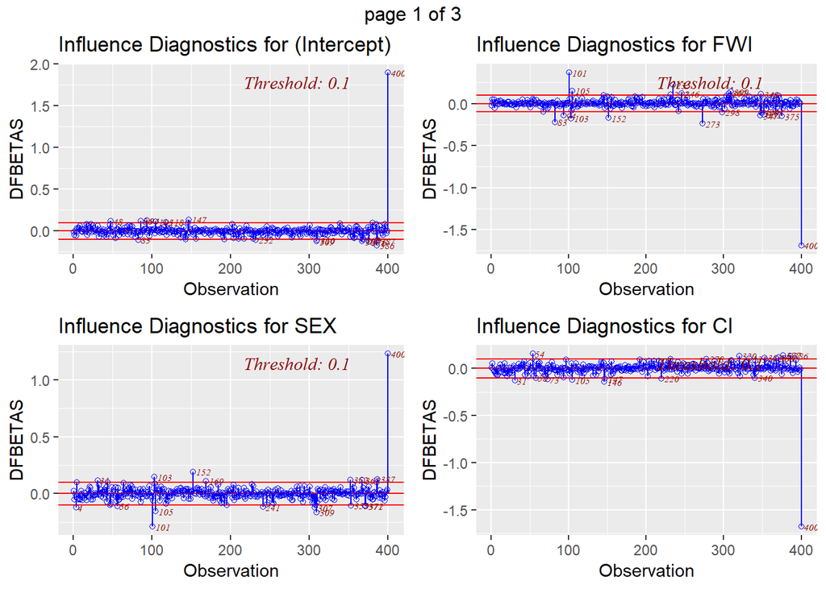

Figure 13. Standardized DFBETA plots for `model_1`

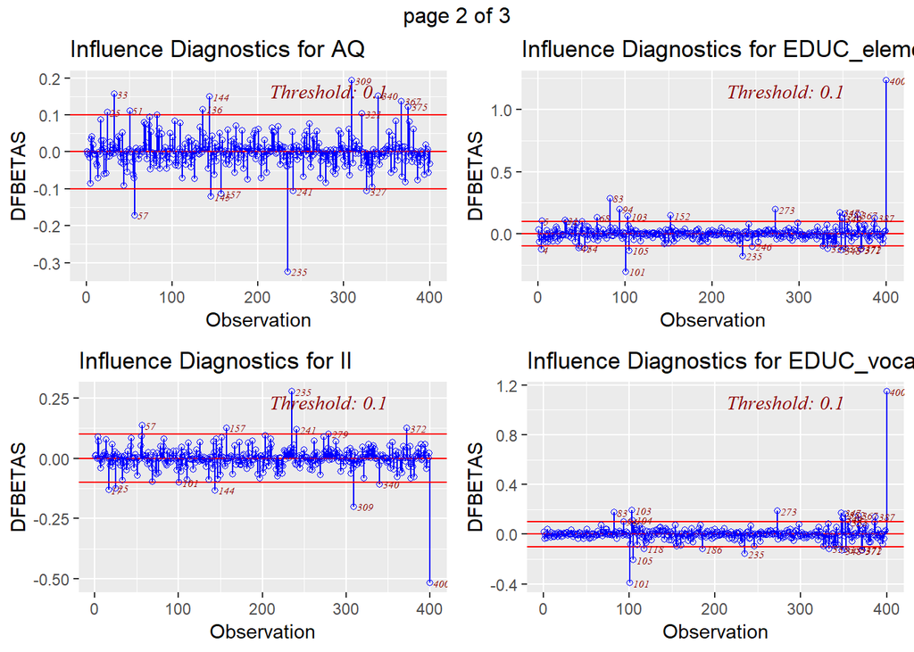

Figure 13. Standardized DFBETA plots for `model_1`

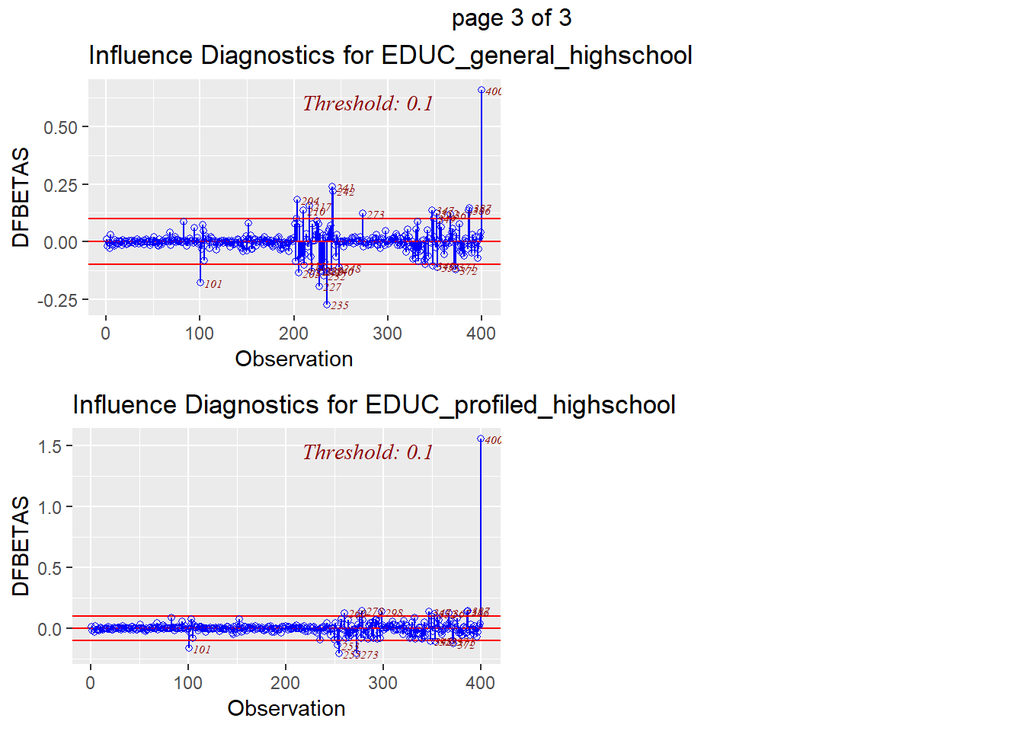

Figure 13. Standardized DFBETA plots for `model_1`

```r
ols_plot_dfbetas(model_1)
```

From the plots, we can see that the observation no. `400` has strong influence on coefficients for many variables.

Let’s examine other metrics.

```r
# Standardize DFFITS
dffits_vec <- dffits(model_1) > (2 / sqrt(dim(data_clean)[2] / dim(data_clean[1])))
cat(which(dffits_vec == TRUE))
```

```
## 400
```

DFFITS point to one problematic observation - observation `400`.

```r
# Leverage statistic
hatvals <- hatvalues(model_1)
cat('More conservative criterion:')
```

```
## More conservative criterion:
```

```r
cat(which((hatvals > 2*(dim(data_clean)[2] / dim(data_clean)[1])) == TRUE))
```

```
## 224 234 235 246 400
```

```r
cat('Less conservative criterion:')
```

```
## Less conservative criterion:
```

```r
cat(which((hatvals > 3*(dim(data_clean)[2] / dim(data_clean)[1])) == TRUE))
```

```
## 400
```

Leverage statistic points to observations `224`, `234`, `235`, `246`, and `400` (more conservative) or only `400` (less conservative) as problematic (Sarkar, nd)

```r
# Cook's distance
c_dist <- cooks.distance(model_1)
sum(c_dist > 1)
```

```
## [1] 0
```

As suggested by Cook (1982), observations with $D_i > 1$ can be interpreted as influential when the dataset is ‘large enough’ (Cook et al., 1982). There are no such observations in the data.

Another heuristic says that observations with $D_i > 3 * \mu(D)$ can be treated as influential.

```r
which((c_dist > 3*mean(c_dist)) == TRUE)
```

```
##  83 101 235 241 273 309 386 400
##  83 101 235 241 273 309 386 400
```

This heuristic reveals that following obseravtions might cause problems:

`83`, `101`, `235`, `241`, `273`, `309`, `386`, `400`.

Observation `400` seems the most problematic.

It also seems very extreme and unlikely to bring any business value.

I decide to remove this observation and re-fit the model.

```r
data_clean_NO <- data_clean %>% slice(-400)
```

Re-fit the model.

```r
model_2 <- lm(MONEY ~ ., data_clean_NO)
```

```r
summary(model_2)
```

```
##
## Call:
## lm(formula = MONEY ~ ., data = data_clean_NO)
##
## Residuals:
##     Min      1Q  Median      3Q     Max
## -45.447  -9.528   0.358   9.589  41.285
##
## Coefficients:
##                           Estimate Std. Error t value Pr(>|t|)
## (Intercept)              -16.00501    3.78899  -4.224 2.99e-05 ***
## SEX                       -7.82985    1.64624  -4.756 2.78e-06 ***
## FWI                        0.46647    0.04387  10.633  < 2e-16 ***
## CI                         0.59540    0.03811  15.623  < 2e-16 ***
## AQ                         0.27071    0.07627   3.549 0.000433 ***
## II                         0.28051    0.07759   3.615 0.000339 ***
## EDUC_elementary          -33.94305    3.51512  -9.656  < 2e-16 ***
## EDUC_vocational          -25.96466    3.09065  -8.401 8.40e-16 ***
## EDUC_general_highschool  -10.80376    2.76609  -3.906 0.000111 ***
## EDUC_profiled_highschool -14.24437    2.73452  -5.209 3.08e-07 ***
## ---
## Signif. codes:  0 '***' 0.001 '**' 0.01 '*' 0.05 '.' 0.1 ' ' 1
##
## Residual standard error: 14.07 on 389 degrees of freedom
## Multiple R-squared:  0.5727, Adjusted R-squared:  0.5628
## F-statistic: 57.92 on 9 and 389 DF,  p-value: < 2.2e-16
```

The fit seems much better as expressed by lower $p$ and higher $R^2$ ($R^2_{adj} = .48$ vs $R^2_{adj} = .56$) values. The new model offers better fit to the data than model with no predictors as indicated by $F$ test ($F(9, 389) = 57.92,\ p < .001$)

Let’s examine diagnostic plots of the new fit:

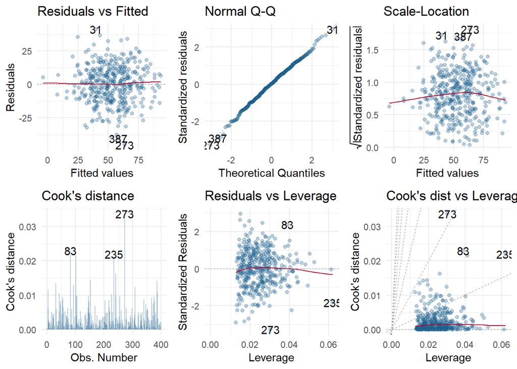

Figure 14. Diagnostic plots for `model_2`

```r
autoplot(model_2, colour = color, smooth.colour = color3,
         alpha = .3,
         which = 1:6,
         ncol  = 3) + theme_minimal()
```

The current plots indicate that:

- Linearity assumption is fulfilled (fitted values vs residuals plot)
- Normal Q-Q plot indicates that distribution of residuals is normal or very close to normal
- Scale location plot reveals that there might be a slight problem with homoscedasticity.
- Residual vs leverage plot indicates that there are no extreme outliers / influential cases anymore. Further deletions could possibly improve the model fit (e.g. deletions of points `235` or `273`), but that could possibly cause overfitting and hurt model’s over generalizability and predictive power.

Just to confirm normality of residuals, let’s see the results of Shapiro test for normality:

```r
shapiro.test(residuals(model_2))
```

```
##
##  Shapiro-Wilk normality test
##
## data:  residuals(model_2)
## W = 0.9967, p-value = 0.5923
```

Test is non-significant ($p = .59$), indicating lack of violation of normality.

### Homoscedasticity

Building on top of visual inspection, let’s check heteroscedasticity using Breush-Pagan and NCV tests.

```r
lmtest::bptest(model_2)
```

```
##
##  studentized Breusch-Pagan test
##
## data:  model_2
## BP = 5.2944, df = 9, p-value = 0.8079
```

```r
car::ncvTest(model_2)
```

```
## Non-constant Variance Score Test
## Variance formula: ~ fitted.values
## Chisquare = 0.02481138, Df = 1, p = 0.87484
```

Both tests demonstrated insignificant result at customary level $p < .05$. We can assume that homoscedasticity assumption is met for `model_2`.

### Multicollinearity

Now, let’s examine if the model does not suffer from multicollinearity.

```r
# Correlation matrix
cor_mtrx <- cor(data_clean_NO)
```

```r
# Check all corrs > .8
which((cor_mtrx[cor_mtrx > .8] && cor_mtrx[cor_mtrx != 1]) == TRUE)
```

```
## [1] 1
```

```r
print(cor.test(data_clean_NO$AQ, data_clean_NO$II))
```

```
##
##  Pearson's product-moment correlation
##
## data:  data_clean_NO$AQ and data_clean_NO$II
## t = 38.626, df = 397, p-value < 2.2e-16
## alternative hypothesis: true correlation is not equal to 0
## 95 percent confidence interval:
##  0.8661220 0.9077041
## sample estimates:
##       cor
## 0.8887271
```

It seems that correlation between `AQ` and `II` might be potentially problematic. Let’s see Variance Inflation Factor values for `model_2`.

```r
model_2_vif = vif(model_2)
print(model_2_vif)
```

```
##                      SEX                      FWI                       CI
##                 1.365538                 4.015182                 1.217330
##                       AQ                       II          EDUC_elementary
##                 4.914089                 4.923837                 4.677225
##          EDUC_vocational  EDUC_general_highschool EDUC_profiled_highschool
##                 3.615828                 1.661241                 1.651934
```

```r
cat("\nTolerance: ", 1 / model_2_vif)
```

```
##
## Tolerance:  0.7323121 0.2490547 0.8214697 0.2034965 0.2030937 0.213802 0.2765619 0.6019595 0.605351
```

A well known heuristic says that when $VIF < 5$ then model does not suffer a serious multicollinearity.

Nevertheless, let’s temporarily remove one of the highest VIF variables and see how it influences model fit. $VIF$ is the highest for `II`.

```r
model_2_1 <- lm(MONEY ~ ., data_clean_NO %>% select(-II))
```

```r
summary(model_2_1)
```

```
##
## Call:
## lm(formula = MONEY ~ ., data = data_clean_NO %>% select(-II))
##
## Residuals:
##     Min      1Q  Median      3Q     Max
## -46.913  -9.220   0.493   9.801  40.691
##
## Coefficients:
##                           Estimate Std. Error t value Pr(>|t|)
## (Intercept)              -12.47178    3.71701  -3.355  0.00087 ***
## SEX                       -8.05946    1.67028  -4.825 2.01e-06 ***
## FWI                        0.47051    0.04453  10.566  < 2e-16 ***
## CI                         0.57463    0.03825  15.021  < 2e-16 ***
## AQ                         0.50755    0.03966  12.799  < 2e-16 ***
## EDUC_elementary          -34.50744    3.56559  -9.678  < 2e-16 ***
## EDUC_vocational          -26.69423    3.13142  -8.525 3.41e-16 ***
## EDUC_general_highschool  -11.55986    2.80053  -4.128 4.48e-05 ***
## EDUC_profiled_highschool -14.32243    2.77643  -5.159 3.97e-07 ***
## ---
## Signif. codes:  0 '***' 0.001 '**' 0.01 '*' 0.05 '.' 0.1 ' ' 1
##
## Residual standard error: 14.29 on 390 degrees of freedom
## Multiple R-squared:  0.5583, Adjusted R-squared:  0.5492
## F-statistic: 61.62 on 8 and 390 DF,  p-value: < 2.2e-16
```

Removing `II` has worsen the model fit. I’ll keep this variable.

### Autocorrelation (error term independence)

To examine autocorrelation we’ll employ Durbin-Watson test. This test examines first order autocorrelation in residuals, testing for null hypothesis that autocorrelation does not exist.

```r
# Durbin-Watson test
durbinWatsonTest(model_2)
```

```
##  lag Autocorrelation D-W Statistic p-value
##    1     -0.04096837      2.079177   0.646
##  Alternative hypothesis: rho != 0
```

## Test if `EDUC` is significant as a category

```r
model_2_NO_NE <- lm(MONEY ~ SEX + FWI + CI + AQ + II, data_clean_NO)
summary(model_2_NO_NE)
```

```
##
## Call:
## lm(formula = MONEY ~ SEX + FWI + CI + AQ + II, data = data_clean_NO)
##
## Residuals:
##    Min     1Q Median     3Q    Max
## -51.19 -10.39   0.94  10.39  40.46
##
## Coefficients:
##              Estimate Std. Error t value Pr(>|t|)
## (Intercept) -17.42944    4.13333  -4.217 3.08e-05 ***
## SEX          -0.84230    1.65296  -0.510  0.61064
## FWI           0.10414    0.02638   3.948 9.34e-05 ***
## CI            0.55756    0.04210  13.243  < 2e-16 ***
## AQ            0.37737    0.08399   4.493 9.24e-06 ***
## II            0.30930    0.08611   3.592  0.00037 ***
## ---
## Signif. codes:  0 '***' 0.001 '**' 0.01 '*' 0.05 '.' 0.1 ' ' 1
##
## Residual standard error: 15.69 on 393 degrees of freedom
## Multiple R-squared:  0.4634, Adjusted R-squared:  0.4566
## F-statistic: 67.88 on 5 and 393 DF,  p-value: < 2.2e-16
```

```r
anova(model_2_NO_NE, model_2)
```

```
## Analysis of Variance Table
##
## Model 1: MONEY ~ SEX + FWI + CI + AQ + II
## Model 2: MONEY ~ SEX + FWI + CI + AQ + II + EDUC_elementary + EDUC_vocational +
##     EDUC_general_highschool + EDUC_profiled_highschool
##   Res.Df   RSS Df Sum of Sq      F    Pr(>F)
## 1    393 96699
## 2    389 77009  4     19690 24.865 < 2.2e-16 ***
## ---
## Signif. codes:  0 '***' 0.001 '**' 0.01 '*' 0.05 '.' 0.1 ' ' 1
```

Results of ANOVA ($F(4, 389) = 24.87,\ p < .001$) confirm that the more complex model (`model_2`) offers a better fit to the data than the simpler model (without `EDUC`).

## Interpretation

```r
tab_model(model_2,
          show.std = TRUE,
          show.ci  = FALSE,
          show.se  = TRUE,
          show.fstat = TRUE,
          show.p = TRUE,
          show.stat = TRUE,
          p.style = 'asterisk',
          strings = c(est = 'b', se = 'SE(b)', std = '$beta$', std_se = 'SE(beta)', stat = '$t$'),
          title = "Table 1. Results of multiple regression analysis for 'model_2'")
```

Table 1. Results of multiple regression analysis for ‘model_2’

MONEY

Predictors

Estimates

SE(b)

$beta$

standardized SE(b)

$t$

(Intercept)

-16.01 ***

3.79

-4.22

SEX

-7.83 ***

1.65

-0.18

0.04

-4.76

FWI

0.47 ***

0.04

0.71

0.07

10.63

CI

0.60 ***

0.04

0.57

0.04

15.62

AQ

0.27 ***

0.08

0.26

0.07

3.55

II

0.28 ***

0.08

0.27

0.07

3.62

EDUC elementary

-33.94 ***

3.52

-0.69

0.07

-9.66

EDUC vocational

-25.96 ***

3.09

-0.53

0.06

-8.40

EDUC general highschool

-10.80 ***

2.77

-0.17

0.04

-3.91

EDUC profiled highschool

-14.24 ***

2.73

-0.22

0.04

-5.21

Observations

399

R<sup>2</sup> / R<sup>2</sup> adjusted

0.573 / 0.563

- p<0.05 ** p<0.01 *** p<0.001

The overall regression model is significant ($F(9, 389) = 57.92, p < .001$) with all the included predictors showing a significant contribution in explaining the dependent variable. The proposed model explains over 56% of variance in wages ($R^2_{adj} = .56$).

## References

- Box, G.E. (1976). Science and Statistics, *Journal of the American Statistical Association*, *71*(356), 791-799.
- Cook, R.D., Weisberg, S. (1982). *Residuals and Influence in Regression*. New York, NY: Chapman & Hall.
- Cleveland, W.S. (1979). Robust Locally Weighted Regression and Smoothing Scatterplots, *Journal of the American Statistical Association*, *74*(368), 829-836.
- Fox, J., Weisberg, S. (2019). *An R Companion to Applied Regression*. Thousand Oaks, CA: Sage.
- Hlavac, M. (2018). *stargazer: Well-Formatted Regression and Summary Statistics Tables. R package version 5.2.2*. Source: https://CRAN.R-project.org/package=stargazer
- Sarkar, D. (nd). Unusual and Influential Observations. https://www.isid.ac.in/~deepayan/RT2018/notes/unusual-data.pdf
- Wickham, H. (2016). *ggplot2: Elegant Graphics for Data Analysis*. New York: Springer-Verlag.